# Project 2B: Disney+ Data

Tim Partridge

Monday, December 06, 2021 @ 04:33 PM

## Setup

### Packages Used

```r
library(dplyr)
library(tidyverse)
library(readxl)
library(jsonlite)
library(knitr)
library(writexl)
library(DT)
library(waffle)
```

### Datasets Used

```r
streaming_content <- load("~/git_repositories/STT2860project2/dataprocessed/streamingcontent.Rdata")
glimpse(streaming_content)
```

```
 chr [1:3] "dplus" "strmtv" "strmtv_long"
```

```r
glimpse(dplus)
```

```
Rows: 1,368
Columns: 12
$ show_id      <chr> "s1", "s2", "s3", "s4", "s5", "s6", "s7", "s8", "s9", "s1…
$ type         <chr> "Movie", "Movie", "Movie", "TV Show", "TV Show", "TV Show…
$ title        <chr> "A Spark Story", "Spooky Buddies", "The Fault in Our Star…
$ director     <chr> "Jason Sterman, Leanne Dare", "Robert Vince", "Josh Boone…
$ cast         <chr> "Apthon Corbin, Louis Gonzales", "Tucker Albrizzi, Diedri…
$ country      <chr> NA, "United States, Canada", "United States", "United Sta…
$ date_added   <dttm> 2021-09-24, 2021-09-24, 2021-09-24, 2021-09-22, 2021-09-…
$ release_year <dbl> 2021, 2011, 2014, 2019, 2021, 2021, 2009, 2021, 2016, 202…
$ rating       <chr> "TV-PG", "G", "PG-13", "TV-PG", "TV-Y", "TV-PG", "PG", "T…
$ duration     <chr> "88 min", "93 min", "127 min", "2 Seasons", "1 Season", "…
$ listed_in    <chr> "Documentary", "Comedy, Fantasy, Kids", "Coming of Age, D…
$ description  <chr> "Two Pixar filmmakers strive to bring their uniquely pers…
```

```r
glimpse(strmtv)
```

```
Rows: 5,368
Columns: 10
$ ID                <dbl> 1, 2, 3, 4, 5, 6, 7, 8, 9, 10, 11, 12, 13, 14, 15, 1…
$ Title             <chr> "Breaking Bad", "Stranger Things", "Attack on Titan"…
$ Year              <dbl> 2008, 2016, 2013, 2015, 2017, 2005, 2013, 2010, 2011…
$ Age               <chr> "18+", "16+", "18+", "18+", "16+", "7+", "18+", "18+…
$ IMDb              <chr> "9.4/10", "8.7/10", "9.0/10", "8.8/10", "8.8/10", "9…
$ `Rotten Tomatoes` <chr> "100/100", "96/100", "95/100", "94/100", "93/100", "…
$ Netflix           <dbl> 1, 1, 1, 1, 1, 1, 1, 1, 1, 1, 1, 1, 1, 1, 1, 1, 1, 1…
$ Hulu              <dbl> 0, 0, 1, 0, 0, 0, 0, 0, 0, 0, 0, 1, 0, 1, 0, 0, 0, 0…
$ `Prime Video`     <dbl> 0, 0, 0, 0, 0, 1, 0, 0, 0, 0, 0, 1, 0, 1, 0, 0, 0, 0…
$ `Disney+`         <dbl> 0, 0, 0, 0, 0, 0, 0, 0, 0, 0, 0, 0, 0, 0, 0, 0, 0, 0…
```

```r
glimpse(strmtv_long)
```

```
Rows: 5,774
Columns: 8
$ ID                <dbl> 1, 2, 3, 3, 4, 5, 6, 6, 7, 8, 9, 10, 11, 12, 12, 12,…
$ Title             <chr> "Breaking Bad", "Stranger Things", "Attack on Titan"…
$ Year              <dbl> 2008, 2016, 2013, 2013, 2015, 2017, 2005, 2005, 2013…
$ Age               <chr> "18+", "16+", "18+", "18+", "18+", "16+", "7+", "7+"…
$ IMDb              <chr> "9.4/10", "8.7/10", "9.0/10", "9.0/10", "8.8/10", "8…
$ `Rotten Tomatoes` <chr> "100/100", "96/100", "95/100", "95/100", "94/100", "…
$ Service           <chr> "Netflix", "Netflix", "Netflix", "Hulu", "Netflix", …
$ YesNo             <dbl> 1, 1, 1, 1, 1, 1, 1, 1, 1, 1, 1, 1, 1, 1, 1, 1, 1, 1…
```

### Collaborators

Anna Jenkins

## Visualizations

### Background of the Data

The datasets were downloaded from [Kaggle](https://www.kaggle.com/). You can find the links to their descriptions in the `docsreference` folder.

### Create Analysis Datasets

Complete and run the two scripts found in the `docscripts` folder. Your processed datasets all should be written into the `dataprocessed` folder. Load the resulting `.Rdata` file above under the **Setup** header and use `glimpse()` to explore the structure of each dataset.

#### Dataset #1

The `dplus` dataset contains a variable that gives information about the `rating` for each program offering. Convert the variable into a factor that puts the ratings in (roughly) ascending order of age restriction/audience: `TV-Y`, `TV-Y7`, `TV-Y7-FV`, `TV-G`, `G`, `TV-PG`, `PG`, `PG-13`, `TV-14`. If the `date_added` variable is not already in date format, convert it.

```r
dplus$rating <- factor(dplus$rating, levels = c("TV-Y", "TV-Y7", "TV-Y7-FV", "TV-G", "G",
                                                "TV-PG", "PG", "PG-13", "TV-14"))
```

#### Dataset #2

In the `strmtv` dataset, create a new variable that tells you the total number of streaming services that offer each included program.

```r
strmtv <- strmtv %>%
  mutate(num_services = strmtv$Netflix + strmtv$Hulu + strmtv$`Prime Video` + strmtv$`Disney+`)
```

### Part 1: Violin Plot

Create a violin plot of `release_year` (x-axis) grouped by `type` of program (y-axis) for programs on Disney+. Fill with a color of your choice. Add a boxplot inside the violin plot, as you did in one of the DataCamp exercises. Re-scale the x-axis so that tick marks appear at whole-decade intervals (e.g., 1980, 1990, 2000). Add an appropriate title and axis labels. Use other formatting as you choose to enhance effectiveness/appearance.

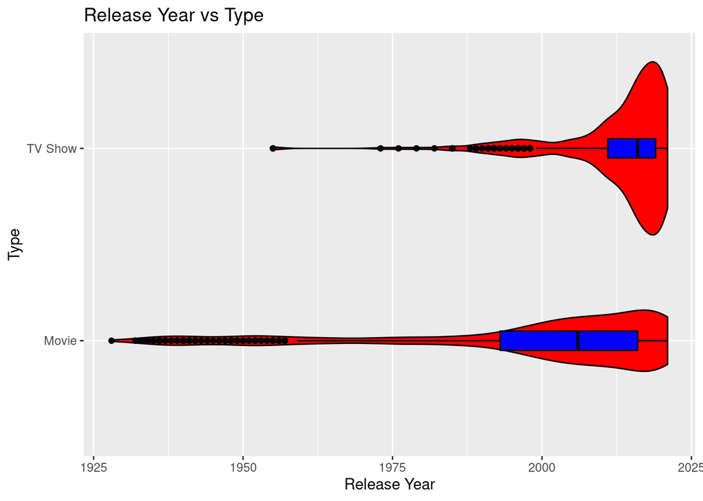

```r
ggplot(dplus, aes(x = release_year, y = type)) +
  geom_violin(color = "black", fill = "red") +
  geom_boxplot(width = 0.1, color = "black", fill = "blue") +
  labs(title = "Release Year vs Type", x = "Release Year", y = "Type")
```

### Part 2: Waffle Plot

[figure not shown]

Create a waffle plot to show the distribution of program `type` on Disney+.

- Give the plot the title “Streaming Content on Disney+”.
- Change the colors of the squares to something other than the defaults.
- Use an x-axis label to indicate roughly how many programs each square represents.

Hint: You can use `count()` to find out how many of each `type` of program there is, then use `prop.table(n)` in a mutate statement (along with some other math) to get percentages. Other methods are also possible.

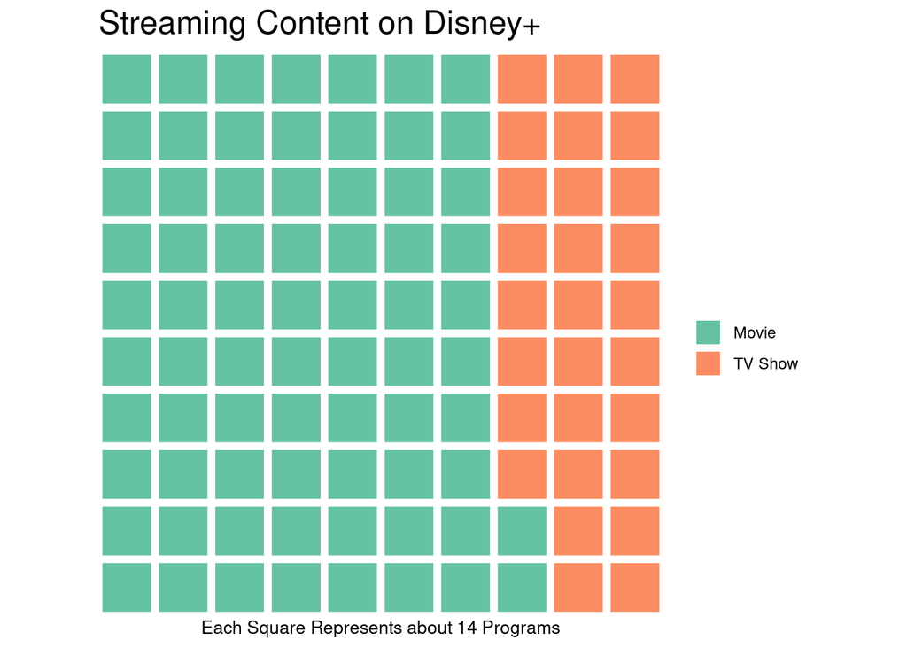

```r
type_count <- count(dplus, type)
count <- type_count %>%
  mutate(percent = round(n/sum(n)*100))
sum_counts = count$percent
names(sum_counts) <- type_count$type
waffle(sum_counts) +
  xlab("Each Square Represents about 14 Programs") +
  labs(title = "Streaming Content on Disney+")
```

### Part 3: Bar Plot

Create a horizontal barplot to show the frequencies of the various `rating` categories for programs on Disney+ (i.e., use `y =` rather than `x =` for the variable you are plotting). You will need to remove a couple `NA` values first. Use faceting by `type` so that you have side-by-side plots for the different program types. Add an appropriate title and axis labels, as well as other formatting of your choice to enhance effectiveness/appearance.

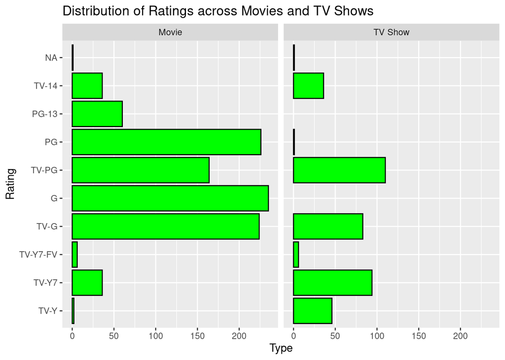

```r
dplus <- dplus[-is.na(dplus$rating),]
ggplot(dplus, aes(y = rating)) +
  geom_bar(color = "black", fill = "green") +
  facet_wrap(~type) +
  labs(title = "Distribution of Ratings across Movies and TV Shows", x = "Type", y = "Rating")
```

### Part 4: Another Plot

Use one of the sets that contains data about the TV shows available on various streaming services to compare the quantity of Disney’s TV show offerings to the quantity of offerings on other streaming services. Use a plot of your choice to enhance the effectiveness/appearance of the plot.

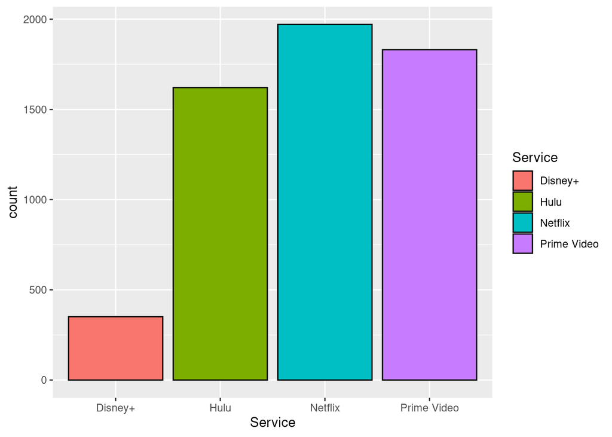

```r
ggplot(strmtv_long, aes(x = Service, fill = Service)) +
  geom_bar(color = "black")
```

## Questions

**Question 1:** Based on your plots, make five informational statements or comparisons regarding the Disney+ streaming service.

**Question 2:** What other data would you like to have, or which existing variables would you like to see transformed, if you were going to do further explorations or visualizations? Give at least two examples.

**ANSWER**

I would have liked to seen how many people are subscribed to each streaming service or even the average length of subscription per service.